# Machine Learning Midterm Project

## Housing Price Prediction

### Ayush Vashistha av64

### Harshvardhan Lad hsl6

### PavitPaul Matharu pm66

### Vedant Kadu vk63

```python
import pandas as pd #Importing all the required libraries
import numpy as np
import seaborn as sns
from sklearn.preprocessing import LabelEncoder
from sklearn.preprocessing import OneHotEncoder
```

```python
test=pd.read_csv(r"F://Dataset/ML_midterm/test.csv") #Loding training and testing dataset into respective dataframe
train=pd.read_csv(r"F://Dataset/ML_midterm/train.csv")
```

```python
train.head()
```

|  | Id | MSSubClass | MSZoning | LotFrontage | LotArea | Street | Alley | LotShape | LandContour | Utilities | ... | PoolArea | PoolQC | Fence | MiscFeature | MiscVal | MoSold | YrSold | SaleType | SaleCondition | SalePrice |
| --- | --- | --- | --- | --- | --- | --- | --- | --- | --- | --- | --- | --- | --- | --- | --- | --- | --- | --- | --- | --- | --- |
| 0 | 1 | 60 | RL | 65.0 | 8450 | Pave | NaN | Reg | Lvl | AllPub | ... | 0 | NaN | NaN | NaN | 0 | 2 | 2008 | WD | Normal | 208500 |
| 1 | 2 | 20 | RL | 80.0 | 9600 | Pave | NaN | Reg | Lvl | AllPub | ... | 0 | NaN | NaN | NaN | 0 | 5 | 2007 | WD | Normal | 181500 |
| 2 | 3 | 60 | RL | 68.0 | 11250 | Pave | NaN | IR1 | Lvl | AllPub | ... | 0 | NaN | NaN | NaN | 0 | 9 | 2008 | WD | Normal | 223500 |
| 3 | 4 | 70 | RL | 60.0 | 9550 | Pave | NaN | IR1 | Lvl | AllPub | ... | 0 | NaN | NaN | NaN | 0 | 2 | 2006 | WD | Abnorml | 140000 |
| 4 | 5 | 60 | RL | 84.0 | 14260 | Pave | NaN | IR1 | Lvl | AllPub | ... | 0 | NaN | NaN | NaN | 0 | 12 | 2008 | WD | Normal | 250000 |

5 rows × 81 columns

```python
train=train.drop('Id', 1) # Drop ID column
```

```python
train.info()
```

```
<class 'pandas.core.frame.DataFrame'>
RangeIndex: 1460 entries, 0 to 1459
Data columns (total 80 columns):
MSSubClass       1460 non-null int64
MSZoning         1460 non-null object
LotFrontage      1201 non-null float64
LotArea          1460 non-null int64
Street           1460 non-null object
Alley            91 non-null object
LotShape         1460 non-null object
LandContour      1460 non-null object
Utilities        1460 non-null object
LotConfig        1460 non-null object
LandSlope        1460 non-null object
Neighborhood     1460 non-null object
Condition1       1460 non-null object
Condition2       1460 non-null object
BldgType         1460 non-null object
HouseStyle       1460 non-null object
OverallQual      1460 non-null int64
OverallCond      1460 non-null int64
YearBuilt        1460 non-null int64
YearRemodAdd     1460 non-null int64
RoofStyle        1460 non-null object
RoofMatl         1460 non-null object
Exterior1st      1460 non-null object
Exterior2nd      1460 non-null object
MasVnrType       1452 non-null object
MasVnrArea       1452 non-null float64
ExterQual        1460 non-null object
ExterCond        1460 non-null object
Foundation       1460 non-null object
BsmtQual         1423 non-null object
BsmtCond         1423 non-null object
BsmtExposure     1422 non-null object
BsmtFinType1     1423 non-null object
BsmtFinSF1       1460 non-null int64
BsmtFinType2     1422 non-null object
BsmtFinSF2       1460 non-null int64
BsmtUnfSF        1460 non-null int64
```

[output cut: 30 more lines]

```
EnclosedPorch    1460 non-null int64
3SsnPorch        1460 non-null int64
ScreenPorch      1460 non-null int64
PoolArea         1460 non-null int64
PoolQC           7 non-null object
Fence            281 non-null object
MiscFeature      54 non-null object
MiscVal          1460 non-null int64
MoSold           1460 non-null int64
YrSold           1460 non-null int64
SaleType         1460 non-null object
SaleCondition    1460 non-null object
SalePrice        1460 non-null int64
dtypes: float64(3), int64(34), object(43)
memory usage: 912.6+ KB
```

#### We can clearly see that we have missing values for few columns

#### & Some of the values are in object format

```python
train.describe()
```

|  | MSSubClass | LotFrontage | LotArea | OverallQual | OverallCond | YearBuilt | YearRemodAdd | MasVnrArea | BsmtFinSF1 | BsmtFinSF2 | ... | WoodDeckSF | OpenPorchSF | EnclosedPorch | 3SsnPorch | ScreenPorch | PoolArea | MiscVal | MoSold | YrSold | SalePrice |
| --- | --- | --- | --- | --- | --- | --- | --- | --- | --- | --- | --- | --- | --- | --- | --- | --- | --- | --- | --- | --- | --- |
| count | 1460.000000 | 1201.000000 | 1460.000000 | 1460.000000 | 1460.000000 | 1460.000000 | 1460.000000 | 1452.000000 | 1460.000000 | 1460.000000 | ... | 1460.000000 | 1460.000000 | 1460.000000 | 1460.000000 | 1460.000000 | 1460.000000 | 1460.000000 | 1460.000000 | 1460.000000 | 1460.000000 |
| mean | 56.897260 | 70.049958 | 10516.828082 | 6.099315 | 5.575342 | 1971.267808 | 1984.865753 | 103.685262 | 443.639726 | 46.549315 | ... | 94.244521 | 46.660274 | 21.954110 | 3.409589 | 15.060959 | 2.758904 | 43.489041 | 6.321918 | 2007.815753 | 180921.195890 |
| std | 42.300571 | 24.284752 | 9981.264932 | 1.382997 | 1.112799 | 30.202904 | 20.645407 | 181.066207 | 456.098091 | 161.319273 | ... | 125.338794 | 66.256028 | 61.119149 | 29.317331 | 55.757415 | 40.177307 | 496.123024 | 2.703626 | 1.328095 | 79442.502883 |
| min | 20.000000 | 21.000000 | 1300.000000 | 1.000000 | 1.000000 | 1872.000000 | 1950.000000 | 0.000000 | 0.000000 | 0.000000 | ... | 0.000000 | 0.000000 | 0.000000 | 0.000000 | 0.000000 | 0.000000 | 0.000000 | 1.000000 | 2006.000000 | 34900.000000 |
| 25% | 20.000000 | 59.000000 | 7553.500000 | 5.000000 | 5.000000 | 1954.000000 | 1967.000000 | 0.000000 | 0.000000 | 0.000000 | ... | 0.000000 | 0.000000 | 0.000000 | 0.000000 | 0.000000 | 0.000000 | 0.000000 | 5.000000 | 2007.000000 | 129975.000000 |
| 50% | 50.000000 | 69.000000 | 9478.500000 | 6.000000 | 5.000000 | 1973.000000 | 1994.000000 | 0.000000 | 383.500000 | 0.000000 | ... | 0.000000 | 25.000000 | 0.000000 | 0.000000 | 0.000000 | 0.000000 | 0.000000 | 6.000000 | 2008.000000 | 163000.000000 |
| 75% | 70.000000 | 80.000000 | 11601.500000 | 7.000000 | 6.000000 | 2000.000000 | 2004.000000 | 166.000000 | 712.250000 | 0.000000 | ... | 168.000000 | 68.000000 | 0.000000 | 0.000000 | 0.000000 | 0.000000 | 0.000000 | 8.000000 | 2009.000000 | 214000.000000 |
| max | 190.000000 | 313.000000 | 215245.000000 | 10.000000 | 9.000000 | 2010.000000 | 2010.000000 | 1600.000000 | 5644.000000 | 1474.000000 | ... | 857.000000 | 547.000000 | 552.000000 | 508.000000 | 480.000000 | 738.000000 | 15500.000000 | 12.000000 | 2010.000000 | 755000.000000 |

8 rows × 37 columns

#### Following heatmap shows in missing values present in the training dataset

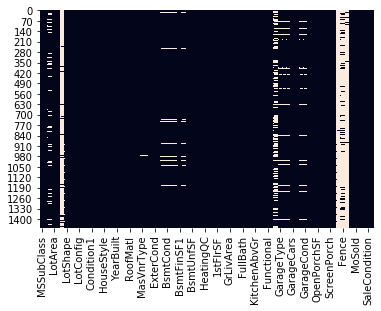

```python
sns.heatmap(train.isnull(), cbar=False)
```

### Dealing with missing data

We used 2 method to deal with the missing values which are present in the dataset.

**1.Drop Missing values:**

[output not shown]

**2.Filling Missing values:**

```
    In this project we are taking the most frequent value of the feature and we are filling that value wherever we have msiing value
```

```python
dropcol=[] #Dropping the columns having missing values more than 500
for col in train.columns:
    if train[col].isna().sum()>500:
        dropcol.append(col)
print(dropcol)
```

```
['Alley', 'FireplaceQu', 'PoolQC', 'Fence', 'MiscFeature']
```

```python
train.drop(['Alley', 'FireplaceQu', 'PoolQC', 'Fence', 'MiscFeature'], axis=1, inplace=True)
test.drop(['Alley', 'FireplaceQu', 'PoolQC', 'Fence', 'MiscFeature'], axis=1, inplace=True)
```

**Now we need to calculate the list of column which have at least one missing value we can fill this columns with the most frequent data present in that column**

```python
col=train.columns
dropcol=[]
for i in range(len(col)):
    if train[col[i]].isna().sum()>0:
        dropcol.append(col[i])
print(dropcol)
```

```
['LotFrontage', 'MasVnrType', 'MasVnrArea', 'BsmtQual', 'BsmtCond', 'BsmtExposure', 'BsmtFinType1', 'BsmtFinType2', 'Electrical', 'GarageType', 'GarageYrBlt', 'GarageFinish', 'GarageQual', 'GarageCond']
```

```python
col=test.columns
dropcol=[]
for i in range(len(col)):
    if test[col[i]].isna().sum()>0:
        dropcol.append(col[i])
print(dropcol)
```

[output not shown]

```python
train['MasVnrType'].fillna(train['MasVnrType'].mode()[0],inplace=True)
train['BsmtQual'].fillna(train['BsmtQual'].mode()[0], inplace=True)
train['BsmtCond'].fillna(train['BsmtCond'].mode()[0], inplace=True)
train['BsmtExposure'].fillna(train['BsmtExposure'].mode()[0], inplace=True)
train['BsmtFinType1'].fillna(train['BsmtFinType1'].mode()[0], inplace=True)
train['BsmtFinType2'].fillna(train['BsmtFinType2'].mode()[0], inplace=True)
train['Electrical'].fillna(train['Electrical'].mode()[0], inplace=True)
train['GarageType'].fillna(train['GarageType'].mode()[0], inplace=True)
train['GarageFinish'].fillna(train['GarageFinish'].mode()[0], inplace=True)
train['GarageQual'].fillna(train['GarageQual'].mode()[0], inplace=True)
train['GarageCond'].fillna(train['GarageCond'].mode()[0], inplace=True)
```

```python
test['MasVnrType'].fillna(test['MasVnrType'].mode()[0],inplace=True)
test['MSZoning'].fillna(test['MSZoning'].mode()[0],inplace=True)
test['Utilities'].fillna(test['Utilities'].mode()[0],inplace=True)
test['Exterior1st'].fillna(test['Exterior1st'].mode()[0],inplace=True)
test['Exterior2nd'].fillna(test['Exterior2nd'].mode()[0],inplace=True)
test['Exterior2nd'].fillna(test['Exterior2nd'].mode()[0],inplace=True)
test['KitchenQual'].fillna(test['KitchenQual'].mode()[0],inplace=True)
test['Functional'].fillna(test['Functional'].mode()[0],inplace=True)
test['GarageType'].fillna(test['GarageType'].mode()[0],inplace=True)
test['GarageFinish'].fillna(test['GarageFinish'].mode()[0],inplace=True)
test['GarageQual'].fillna(test['GarageQual'].mode()[0],inplace=True)
test['GarageCond'].fillna(test['GarageCond'].mode()[0],inplace=True)
test['SaleType'].fillna(test['SaleType'].mode()[0],inplace=True)
test['BsmtQual'].fillna(test['BsmtQual'].mode()[0], inplace=True)
test['BsmtCond'].fillna(test['BsmtCond'].mode()[0], inplace=True)
test['BsmtExposure'].fillna(test['BsmtExposure'].mode()[0], inplace=True)
test['BsmtFinType1'].fillna(test['BsmtFinType1'].mode()[0], inplace=True)
test['BsmtFinType2'].fillna(test['BsmtFinType2'].mode()[0], inplace=True)
test['GarageType'].fillna(test['GarageType'].mode()[0], inplace=True)
test['GarageFinish'].fillna(test['GarageFinish'].mode()[0], inplace=True)
test['GarageQual'].fillna(test['GarageQual'].mode()[0], inplace=True)
test['GarageCond'].fillna(test['GarageCond'].mode()[0], inplace=True)
```

```python
train['LotFrontage'].fillna(train['LotFrontage'].median(),inplace=True)
train['MasVnrArea'].fillna(train['MasVnrArea'].median(), inplace=True)
train['GarageYrBlt'].fillna(train['GarageYrBlt'].median(), inplace=True)
```

```python
test['LotFrontage'].fillna(test['LotFrontage'].median(),inplace=True)
test['MasVnrArea'].fillna(test['MasVnrArea'].median(), inplace=True)
test['BsmtFinSF1'].fillna(test['BsmtFinSF1'].median(), inplace=True)
test['BsmtFinSF2'].fillna(test['BsmtFinSF2'].median(), inplace=True)
test['BsmtUnfSF'].fillna(test['BsmtUnfSF'].median(), inplace=True)
test['TotalBsmtSF'].fillna(test['TotalBsmtSF'].median(), inplace=True)
test['BsmtFullBath'].fillna(test['BsmtFullBath'].median(), inplace=True)
test['BsmtHalfBath'].fillna(test['BsmtHalfBath'].median(), inplace=True)
test['GarageYrBlt'].fillna(test['GarageYrBlt'].median(), inplace=True)
test['GarageCars'].fillna(test['GarageCars'].median(), inplace=True)
test['GarageYrBlt'].fillna(test['GarageYrBlt'].median(), inplace=True)
test['GarageArea'].fillna(test['GarageArea'].median(), inplace=True)
```

```python
train.head()
```

|  | MSSubClass | MSZoning | LotFrontage | LotArea | Street | LotShape | LandContour | Utilities | LotConfig | LandSlope | ... | EnclosedPorch | 3SsnPorch | ScreenPorch | PoolArea | MiscVal | MoSold | YrSold | SaleType | SaleCondition | SalePrice |
| --- | --- | --- | --- | --- | --- | --- | --- | --- | --- | --- | --- | --- | --- | --- | --- | --- | --- | --- | --- | --- | --- |
| 0 | 60 | RL | 65.0 | 8450 | Pave | Reg | Lvl | AllPub | Inside | Gtl | ... | 0 | 0 | 0 | 0 | 0 | 2 | 2008 | WD | Normal | 208500 |
| 1 | 20 | RL | 80.0 | 9600 | Pave | Reg | Lvl | AllPub | FR2 | Gtl | ... | 0 | 0 | 0 | 0 | 0 | 5 | 2007 | WD | Normal | 181500 |
| 2 | 60 | RL | 68.0 | 11250 | Pave | IR1 | Lvl | AllPub | Inside | Gtl | ... | 0 | 0 | 0 | 0 | 0 | 9 | 2008 | WD | Normal | 223500 |
| 3 | 70 | RL | 60.0 | 9550 | Pave | IR1 | Lvl | AllPub | Corner | Gtl | ... | 272 | 0 | 0 | 0 | 0 | 2 | 2006 | WD | Abnorml | 140000 |
| 4 | 60 | RL | 84.0 | 14260 | Pave | IR1 | Lvl | AllPub | FR2 | Gtl | ... | 0 | 0 | 0 | 0 | 0 | 12 | 2008 | WD | Normal | 250000 |

5 rows × 75 columns

```python
train.isnull().sum().sum()
```

```
0
```

```python
test.isnull().sum().sum()
```

```
0
```

**We are left with the zero missing values in our dataset**

```python
lis=list(train.select_dtypes(object).columns)
pd.Series(lis)
```

```
0          MSZoning
1            Street
2          LotShape
3       LandContour
4         Utilities
5         LotConfig
6         LandSlope
7      Neighborhood
8        Condition1
9        Condition2
10         BldgType
11       HouseStyle
12        RoofStyle
13         RoofMatl
14      Exterior1st
```

[output cut: 24 more lines]

### Label Encoding

```python
le=LabelEncoder()
from sklearn.preprocessing import LabelEncoder
for k in lis:
    if k in train.columns:
        i = train.columns.get_loc(k)
        train.iloc[:,i] = train.apply(lambda i:le.fit_transform(i.astype(str)), axis=0, result_type='expand')
```

```python
train.head()
```

|  | MSSubClass | MSZoning | LotFrontage | LotArea | Street | LotShape | LandContour | Utilities | LotConfig | LandSlope | ... | EnclosedPorch | 3SsnPorch | ScreenPorch | PoolArea | MiscVal | MoSold | YrSold | SaleType | SaleCondition | SalePrice |
| --- | --- | --- | --- | --- | --- | --- | --- | --- | --- | --- | --- | --- | --- | --- | --- | --- | --- | --- | --- | --- | --- |
| 0 | 60 | 3 | 65.0 | 8450 | 1 | 3 | 3 | 0 | 4 | 0 | ... | 0 | 0 | 0 | 0 | 0 | 2 | 2008 | 8 | 4 | 208500 |
| 1 | 20 | 3 | 80.0 | 9600 | 1 | 3 | 3 | 0 | 2 | 0 | ... | 0 | 0 | 0 | 0 | 0 | 5 | 2007 | 8 | 4 | 181500 |
| 2 | 60 | 3 | 68.0 | 11250 | 1 | 0 | 3 | 0 | 4 | 0 | ... | 0 | 0 | 0 | 0 | 0 | 9 | 2008 | 8 | 4 | 223500 |
| 3 | 70 | 3 | 60.0 | 9550 | 1 | 0 | 3 | 0 | 0 | 0 | ... | 272 | 0 | 0 | 0 | 0 | 2 | 2006 | 8 | 0 | 140000 |
| 4 | 60 | 3 | 84.0 | 14260 | 1 | 0 | 3 | 0 | 2 | 0 | ... | 0 | 0 | 0 | 0 | 0 | 12 | 2008 | 8 | 4 | 250000 |

5 rows × 75 columns

```python
le=LabelEncoder()
from sklearn.preprocessing import LabelEncoder
for k in lis:
    if k in test.columns:
        i = test.columns.get_loc(k)
        test.iloc[:,i] = test.apply(lambda i:le.fit_transform(i.astype(str)), axis=0, result_type='expand')
```

```python
test.head()
```

|  | Id | MSSubClass | MSZoning | LotFrontage | LotArea | Street | LotShape | LandContour | Utilities | LotConfig | ... | OpenPorchSF | EnclosedPorch | 3SsnPorch | ScreenPorch | PoolArea | MiscVal | MoSold | YrSold | SaleType | SaleCondition |
| --- | --- | --- | --- | --- | --- | --- | --- | --- | --- | --- | --- | --- | --- | --- | --- | --- | --- | --- | --- | --- | --- |
| 0 | 1461 | 20 | 2 | 80.0 | 11622 | 1 | 3 | 3 | 0 | 4 | ... | 0 | 0 | 0 | 120 | 0 | 0 | 6 | 2010 | 8 | 4 |
| 1 | 1462 | 20 | 3 | 81.0 | 14267 | 1 | 0 | 3 | 0 | 0 | ... | 36 | 0 | 0 | 0 | 0 | 12500 | 6 | 2010 | 8 | 4 |
| 2 | 1463 | 60 | 3 | 74.0 | 13830 | 1 | 0 | 3 | 0 | 4 | ... | 34 | 0 | 0 | 0 | 0 | 0 | 3 | 2010 | 8 | 4 |
| 3 | 1464 | 60 | 3 | 78.0 | 9978 | 1 | 0 | 3 | 0 | 4 | ... | 36 | 0 | 0 | 0 | 0 | 0 | 6 | 2010 | 8 | 4 |
| 4 | 1465 | 120 | 3 | 43.0 | 5005 | 1 | 0 | 1 | 0 | 4 | ... | 82 | 0 | 0 | 144 | 0 | 0 | 1 | 2010 | 8 | 4 |

5 rows × 75 columns

### Creating new featuers

```python
train['total_floors'] = train['2ndFlrSF'] + train['1stFlrSF']
train= train.drop("1stFlrSF",1)
train= train.drop("2ndFlrSF",1)
```

```python
test['total_floors'] = test['2ndFlrSF'] + test['1stFlrSF']
test= test.drop("1stFlrSF",1)
test= test.drop("2ndFlrSF",1)
```

```python
train['YearsSinceRemodel'] = train['YearRemodAdd'].astype(int)-train['YearBuilt'].astype(int)
train=train.drop("YearRemodAdd",1)
train=train.drop("YearBuilt",1)
```

```python
test['YearsSinceRemodel'] =test['YearRemodAdd'].astype(int)-test['YearBuilt'].astype(int)
test=test.drop("YearRemodAdd",1)
test=test.drop("YearBuilt",1)
```

```python
train['Total_porch_sf'] = (train['OpenPorchSF'] + train['WoodDeckSF'])
train=train.drop('OpenPorchSF',1)
train=train.drop('WoodDeckSF',1)
```

```python
test['Total_porch_sf']=(test['OpenPorchSF'] +test['WoodDeckSF'])
test=test.drop('OpenPorchSF',1)
test=test.drop('WoodDeckSF',1)
```

```python
train['hasfireplace'] = train['Fireplaces'].apply(lambda x: 1 if x > 0 else 0)
train=train.drop('Fireplaces',1)
```

```python
test['hasfireplace'] = test['Fireplaces'].apply(lambda x: 1 if x > 0 else 0)
test=test.drop('Fireplaces',1)
```

```python
train['Garage_Overall']=train['OverallQual']+train['GarageArea']
train=train.drop('OverallQual',1)
train=train.drop('GarageArea',1)
```

```python
test['Garage_Overall']=test['OverallQual']+test['GarageArea']
test=test.drop('OverallQual',1)
test=test.drop('GarageArea',1)
```

```python
train.head()
```

|  | MSSubClass | MSZoning | LotFrontage | LotArea | Street | LotShape | LandContour | Utilities | LotConfig | LandSlope | ... | MoSold | YrSold | SaleType | SaleCondition | SalePrice | total_floors | YearsSinceRemodel | Total_porch_sf | hasfireplace | Garage_Overall |
| --- | --- | --- | --- | --- | --- | --- | --- | --- | --- | --- | --- | --- | --- | --- | --- | --- | --- | --- | --- | --- | --- |
| 0 | 60 | 3 | 65.0 | 8450 | 1 | 3 | 3 | 0 | 4 | 0 | ... | 2 | 2008 | 8 | 4 | 208500 | 1710 | 0 | 61 | 0 | 555 |
| 1 | 20 | 3 | 80.0 | 9600 | 1 | 3 | 3 | 0 | 2 | 0 | ... | 5 | 2007 | 8 | 4 | 181500 | 1262 | 0 | 298 | 1 | 466 |
| 2 | 60 | 3 | 68.0 | 11250 | 1 | 0 | 3 | 0 | 4 | 0 | ... | 9 | 2008 | 8 | 4 | 223500 | 1786 | 1 | 42 | 1 | 615 |
| 3 | 70 | 3 | 60.0 | 9550 | 1 | 0 | 3 | 0 | 0 | 0 | ... | 2 | 2006 | 8 | 0 | 140000 | 1717 | 55 | 35 | 1 | 649 |
| 4 | 60 | 3 | 84.0 | 14260 | 1 | 0 | 3 | 0 | 2 | 0 | ... | 12 | 2008 | 8 | 4 | 250000 | 2198 | 0 | 276 | 1 | 844 |

5 rows × 71 columns

```python
test.head()
```

|  | Id | MSSubClass | MSZoning | LotFrontage | LotArea | Street | LotShape | LandContour | Utilities | LotConfig | ... | MiscVal | MoSold | YrSold | SaleType | SaleCondition | total_floors | YearsSinceRemodel | Total_porch_sf | hasfireplace | Garage_Overall |
| --- | --- | --- | --- | --- | --- | --- | --- | --- | --- | --- | --- | --- | --- | --- | --- | --- | --- | --- | --- | --- | --- |
| 0 | 1461 | 20 | 2 | 80.0 | 11622 | 1 | 3 | 3 | 0 | 4 | ... | 0 | 6 | 2010 | 8 | 4 | 896 | 0 | 140 | 0 | 735.0 |
| 1 | 1462 | 20 | 3 | 81.0 | 14267 | 1 | 0 | 3 | 0 | 0 | ... | 12500 | 6 | 2010 | 8 | 4 | 1329 | 0 | 429 | 0 | 318.0 |
| 2 | 1463 | 60 | 3 | 74.0 | 13830 | 1 | 0 | 3 | 0 | 4 | ... | 0 | 3 | 2010 | 8 | 4 | 1629 | 1 | 246 | 1 | 487.0 |
| 3 | 1464 | 60 | 3 | 78.0 | 9978 | 1 | 0 | 3 | 0 | 4 | ... | 0 | 6 | 2010 | 8 | 4 | 1604 | 0 | 396 | 1 | 476.0 |
| 4 | 1465 | 120 | 3 | 43.0 | 5005 | 1 | 0 | 1 | 0 | 4 | ... | 0 | 1 | 2010 | 8 | 4 | 1280 | 0 | 82 | 0 | 514.0 |

5 rows × 71 columns

### Feature Selection

**Curse of dimentionality:- model with the huge dimentionliy with 500-600 feature is less likly to perform well and the accuracy will be lower therefore it is very important to reduce and keep only those features who will improve models accuracy. In this project we have applied few feature selection techniques which are as follows**

### 1. Variance

**Dropping constant feature. If the feature is mostly same value, model is not going to learn anything from it**

```python
from sklearn.feature_selection import VarianceThreshold
```

```python
train.head()
```

|  | MSSubClass | MSZoning | LotFrontage | LotArea | Street | LotShape | LandContour | Utilities | LotConfig | LandSlope | ... | MoSold | YrSold | SaleType | SaleCondition | SalePrice | total_floors | YearsSinceRemodel | Total_porch_sf | hasfireplace | Garage_Overall |
| --- | --- | --- | --- | --- | --- | --- | --- | --- | --- | --- | --- | --- | --- | --- | --- | --- | --- | --- | --- | --- | --- |
| 0 | 60 | 3 | 65.0 | 8450 | 1 | 3 | 3 | 0 | 4 | 0 | ... | 2 | 2008 | 8 | 4 | 208500 | 1710 | 0 | 61 | 0 | 555 |
| 1 | 20 | 3 | 80.0 | 9600 | 1 | 3 | 3 | 0 | 2 | 0 | ... | 5 | 2007 | 8 | 4 | 181500 | 1262 | 0 | 298 | 1 | 466 |
| 2 | 60 | 3 | 68.0 | 11250 | 1 | 0 | 3 | 0 | 4 | 0 | ... | 9 | 2008 | 8 | 4 | 223500 | 1786 | 1 | 42 | 1 | 615 |
| 3 | 70 | 3 | 60.0 | 9550 | 1 | 0 | 3 | 0 | 0 | 0 | ... | 2 | 2006 | 8 | 0 | 140000 | 1717 | 55 | 35 | 1 | 649 |
| 4 | 60 | 3 | 84.0 | 14260 | 1 | 0 | 3 | 0 | 2 | 0 | ... | 12 | 2008 | 8 | 4 | 250000 | 2198 | 0 | 276 | 1 | 844 |

5 rows × 71 columns

```python
var_thres=VarianceThreshold(threshold=0.1)
var_thres.fit(train)
```

```
VarianceThreshold(threshold=0.1)
```

```python
sum(var_thres.get_support())
```

```
63
```

```python
var_thres.get_support()
```

```
array([ True,  True,  True,  True, False,  True,  True, False,  True,
       False,  True,  True, False,  True,  True,  True,  True,  True,
        True,  True,  True,  True,  True,  True,  True,  True,  True,
        True,  True,  True,  True,  True,  True,  True, False,  True,
       False,  True,  True,  True,  True, False,  True,  True,  True,
       False,  True,  True,  True,  True,  True,  True,  True,  True,
        True,  True,  True,  True,  True,  True,  True,  True,  True,
        True,  True,  True,  True,  True,  True,  True,  True])
```

```python
less_var_col=[column for column in train.columns
             if column not in train.columns[var_thres.get_support()]]
for column in less_var_col:
    print(column)
```

```
Street
Utilities
LandSlope
Condition2
Heating
CentralAir
BsmtHalfBath
KitchenAbvGr
```

```python
train=train.drop(less_var_col,axis=1)
test=test.drop(less_var_col,axis=1)
```

```python
train.head()
```

|  | MSSubClass | MSZoning | LotFrontage | LotArea | LotShape | LandContour | LotConfig | Neighborhood | Condition1 | BldgType | ... | MoSold | YrSold | SaleType | SaleCondition | SalePrice | total_floors | YearsSinceRemodel | Total_porch_sf | hasfireplace | Garage_Overall |
| --- | --- | --- | --- | --- | --- | --- | --- | --- | --- | --- | --- | --- | --- | --- | --- | --- | --- | --- | --- | --- | --- |
| 0 | 60 | 3 | 65.0 | 8450 | 3 | 3 | 4 | 5 | 2 | 0 | ... | 2 | 2008 | 8 | 4 | 208500 | 1710 | 0 | 61 | 0 | 555 |
| 1 | 20 | 3 | 80.0 | 9600 | 3 | 3 | 2 | 24 | 1 | 0 | ... | 5 | 2007 | 8 | 4 | 181500 | 1262 | 0 | 298 | 1 | 466 |
| 2 | 60 | 3 | 68.0 | 11250 | 0 | 3 | 4 | 5 | 2 | 0 | ... | 9 | 2008 | 8 | 4 | 223500 | 1786 | 1 | 42 | 1 | 615 |
| 3 | 70 | 3 | 60.0 | 9550 | 0 | 3 | 0 | 6 | 2 | 0 | ... | 2 | 2006 | 8 | 0 | 140000 | 1717 | 55 | 35 | 1 | 649 |
| 4 | 60 | 3 | 84.0 | 14260 | 0 | 3 | 2 | 15 | 2 | 0 | ... | 12 | 2008 | 8 | 4 | 250000 | 2198 | 0 | 276 | 1 | 844 |

5 rows × 63 columns

### 2.Correlation of featuers with each other

**If two of your feature is highly corelated, you can drop one because they are redundent**

```python
x_train=train.iloc[:,:-1]
```

```python
matrix=x_train.corr().abs()
```

```python
corr_pairs=matrix.unstack()
sorted_pairs = corr_pairs.sort_values(kind="quicksort")
negative_pairs = sorted_pairs[sorted_pairs>0.8]
negative_pairs = negative_pairs[negative_pairs!=1 ]
print(negative_pairs)
```

```
total_floors  TotRmsAbvGrd    0.820088
TotRmsAbvGrd  total_floors    0.820088
              GrLivArea       0.825489
GrLivArea     TotRmsAbvGrd    0.825489
Exterior2nd   Exterior1st     0.854163
Exterior1st   Exterior2nd     0.854163
GrLivArea     total_floors    0.995718
total_floors  GrLivArea       0.995718
dtype: float64
```

```python
train=train.drop(['TotalBsmtSF','TotRmsAbvGrd','Exterior2nd','GarageCars'],axis=1)
test=test.drop(['TotalBsmtSF','TotRmsAbvGrd','Exterior2nd','GarageCars'],axis=1)
```

```python
train.head()
```

|  | MSSubClass | MSZoning | LotFrontage | LotArea | LotShape | LandContour | LotConfig | Neighborhood | Condition1 | BldgType | ... | MoSold | YrSold | SaleType | SaleCondition | SalePrice | total_floors | YearsSinceRemodel | Total_porch_sf | hasfireplace | Garage_Overall |
| --- | --- | --- | --- | --- | --- | --- | --- | --- | --- | --- | --- | --- | --- | --- | --- | --- | --- | --- | --- | --- | --- |
| 0 | 60 | 3 | 65.0 | 8450 | 3 | 3 | 4 | 5 | 2 | 0 | ... | 2 | 2008 | 8 | 4 | 208500 | 1710 | 0 | 61 | 0 | 555 |
| 1 | 20 | 3 | 80.0 | 9600 | 3 | 3 | 2 | 24 | 1 | 0 | ... | 5 | 2007 | 8 | 4 | 181500 | 1262 | 0 | 298 | 1 | 466 |
| 2 | 60 | 3 | 68.0 | 11250 | 0 | 3 | 4 | 5 | 2 | 0 | ... | 9 | 2008 | 8 | 4 | 223500 | 1786 | 1 | 42 | 1 | 615 |
| 3 | 70 | 3 | 60.0 | 9550 | 0 | 3 | 0 | 6 | 2 | 0 | ... | 2 | 2006 | 8 | 0 | 140000 | 1717 | 55 | 35 | 1 | 649 |
| 4 | 60 | 3 | 84.0 | 14260 | 0 | 3 | 2 | 15 | 2 | 0 | ... | 12 | 2008 | 8 | 4 | 250000 | 2198 | 0 | 276 | 1 | 844 |

5 rows × 59 columns

### 3 .Corelation with the target

**If a variable has a very low co relation witht the target, you can drop that feature.**

```python
import matplotlib.pyplot as plt
```

```python
corr=train.corr()
```

```python
x_train=train.iloc[:,:-1]
```

```python
corr
```

|  | MSSubClass | MSZoning | LotFrontage | LotArea | LotShape | LandContour | LotConfig | Neighborhood | Condition1 | BldgType | ... | MoSold | YrSold | SaleType | SaleCondition | SalePrice | total_floors | YearsSinceRemodel | Total_porch_sf | hasfireplace | Garage_Overall |
| --- | --- | --- | --- | --- | --- | --- | --- | --- | --- | --- | --- | --- | --- | --- | --- | --- | --- | --- | --- | --- | --- |
| MSSubClass | 1.000000 | 0.035900 | -0.356718 | -0.139781 | 0.119289 | -0.002940 | 0.075910 | -0.005985 | -0.024762 | 0.746063 | ... | -0.013585 | -0.021407 | 0.012464 | -0.024940 | -0.084284 | 0.071137 | -0.000137 | -0.013645 | -0.034095 | -0.098102 |
| MSZoning | 0.035900 | 1.000000 | -0.105961 | -0.034452 | 0.061887 | -0.017854 | -0.009895 | -0.249679 | -0.027874 | 0.005690 | ... | -0.031496 | -0.020628 | 0.097437 | 0.009494 | -0.166872 | -0.084374 | 0.233800 | -0.078790 | -0.022042 | -0.189594 |
| LotFrontage | -0.356718 | -0.105961 | 1.000000 | 0.304522 | -0.138877 | -0.076080 | -0.177821 | 0.084901 | -0.009341 | -0.408013 | ... | 0.010451 | 0.006380 | -0.031412 | 0.058857 | 0.334771 | 0.367560 | -0.073682 | 0.127757 | 0.212825 | 0.323848 |
| LotArea | -0.139781 | -0.034452 | 0.304522 | 1.000000 | -0.165315 | -0.149083 | -0.121161 | 0.044569 | 0.023846 | -0.205721 | ... | 0.001205 | -0.014261 | 0.012292 | 0.034169 | 0.263843 | 0.264850 | -0.005926 | 0.186935 | 0.182827 | 0.180429 |
| LotShape | 0.119289 | 0.061887 | -0.138877 | -0.165315 | 1.000000 | 0.085434 | 0.221102 | -0.038894 | -0.115003 | 0.116262 | ... | -0.033455 | 0.036449 | -0.000911 | -0.038118 | -0.255580 | -0.178468 | 0.149202 | -0.178559 | -0.204228 | -0.161282 |
| LandContour | -0.002940 | -0.017854 | -0.076080 | -0.149083 | 0.085434 | 1.000000 | -0.025527 | 0.019116 | 0.024801 | 0.051143 | ... | -0.011599 | 0.020507 | -0.025754 | 0.033809 | 0.015453 | -0.059915 | -0.120676 | 0.016079 | -0.030246 | 0.047640 |
| LotConfig | 0.075910 | -0.009895 | -0.177821 | -0.121161 | 0.221102 | -0.025527 | 1.000000 | -0.036597 | 0.021457 | 0.107229 | ... | 0.018902 | -0.005992 | 0.014325 | 0.051579 | -0.067396 | -0.089481 | -0.021170 | -0.055693 | -0.043784 | -0.063991 |
| Neighborhood | -0.005985 | -0.249679 | 0.084901 | 0.044569 | -0.038894 | 0.019116 | -0.036597 | 1.000000 | -0.025401 | 0.005993 | ... | 0.023222 | 0.036697 | -0.036956 | 0.021867 | 0.210851 | 0.146399 | -0.038385 | 0.117298 | 0.080888 | 0.214069 |
| Condition1 | -0.024762 | -0.027874 | -0.009341 | 0.023846 | -0.115003 | 0.024801 | 0.021457 | -0.025401 | 1.000000 | -0.023501 | ... | -0.009868 | -0.009819 | -0.002338 | 0.057747 | 0.091155 | 0.050325 | -0.080105 | 0.078332 | 0.028032 | 0.075580 |
| BldgType | 0.746063 | 0.005690 | -0.408013 | -0.205721 | 0.116262 | 0.051143 | 0.107229 | 0.005993 | -0.023501 | 1.000000 | ... | -0.025764 | 0.002006 | -0.040306 | -0.003530 | -0.085591 | -0.125196 | -0.180046 | -0.028249 | -0.064969 | -0.060877 |
| HouseStyle | 0.397161 | -0.105315 | 0.030567 | -0.033190 | -0.104026 | 0.075234 | -0.032945 | 0.048595 | 0.096714 | 0.066552 | ... | 0.025728 | -0.018005 | 0.048582 | 0.022753 | 0.180163 | 0.271307 | -0.156670 | 0.137910 | 0.116657 | 0.156324 |
| OverallCond | -0.059316 | 0.186951 | -0.053281 | -0.005636 | 0.013693 | -0.045271 | -0.030788 | -0.033609 | -0.032243 | -0.162040 | ... | -0.003511 | 0.043950 | 0.095267 | 0.017758 | -0.077856 | -0.082724 | 0.526147 | -0.017752 | -0.055515 | -0.151563 |
| RoofStyle | -0.117817 | -0.000301 | 0.153999 | 0.077054 | 0.003182 | -0.004246 | -0.010364 | 0.109937 | 0.002956 | -0.054389 | ... | 0.009767 | 0.019385 | -0.032945 | 0.065946 | 0.222405 | 0.159902 | -0.036996 | 0.071031 | 0.126703 | 0.142431 |
| RoofMatl | -0.031336 | 0.005133 | 0.081277 | 0.149837 | -0.071174 | -0.020229 | -0.068465 | -0.007353 | 0.009924 | -0.038424 | ... | 0.034523 | -0.029057 | 0.011475 | -0.045475 | 0.132383 | 0.121671 | -0.002186 | 0.126651 | 0.070979 | 0.047870 |
| Exterior1st | -0.089159 | -0.008558 | 0.075455 | 0.004256 | -0.020463 | -0.011809 | 0.023316 | -0.073718 | 0.013146 | -0.112112 | ... | -0.004962 | -0.040181 | 0.011757 | 0.062552 | 0.103551 | 0.062461 | 0.082209 | 0.076021 | 0.035199 | 0.102072 |
| MasVnrType | -0.029850 | -0.028279 | -0.017693 | -0.008122 | 0.007946 | -0.076066 | 0.001826 | 0.081865 | 0.002483 | -0.028751 | ... | 0.003180 | 0.063067 | -0.024431 | 0.079444 | 0.018216 | -0.053148 | 0.124883 | -0.024143 | -0.067010 | -0.007880 |
| MasVnrArea | 0.023573 | -0.062830 | 0.178469 | 0.103321 | -0.106178 | 0.048274 | -0.031639 | 0.118035 | 0.022398 | 0.043149 | ... | -0.006723 | -0.008317 | -0.055132 | 0.086638 | 0.472614 | 0.397669 | -0.235602 | 0.194059 | 0.259577 | 0.372160 |
| ExterQual | -0.017161 | 0.200536 | -0.184120 | -0.057275 | 0.148818 | -0.003613 | -0.002503 | -0.151595 | -0.074855 | -0.087862 | ... | -0.024720 | -0.036300 | 0.087012 | -0.188571 | -0.636884 | -0.411084 | 0.202871 | -0.278994 | -0.262199 | -0.446008 |
| ExterCond | -0.003254 | -0.096041 | 0.048300 | 0.015160 | -0.029497 | 0.009804 | 0.034898 | 0.033918 | 0.076841 | 0.085067 | ... | 0.019478 | -0.033619 | 0.008787 | 0.054232 | 0.117303 | 0.049382 | -0.268405 | 0.016181 | 0.064057 | 0.138411 |
| Foundation | 0.058126 | -0.235174 | 0.098418 | -0.011081 | -0.135124 | 0.053478 | -0.011755 | 0.066494 | 0.074020 | 0.142892 | ... | -0.001892 | 0.009058 | 0.016484 | 0.140358 | 0.382479 | 0.233196 | -0.413381 | 0.193976 | 0.115197 | 0.334797 |
| BsmtQual | -0.041065 | 0.128245 | -0.169603 | -0.065150 | 0.161208 | -0.003311 | 0.022063 | -0.159363 | -0.112176 | -0.108308 | ... | -0.006646 | 0.025285 | 0.065474 | -0.184479 | -0.618025 | -0.368481 | 0.266626 | -0.308726 | -0.248767 | -0.450186 |
| BsmtCond | -0.013652 | -0.010528 | 0.050604 | 0.012366 | -0.012226 | 0.023160 | 0.033823 | 0.024534 | 0.006562 | 0.032224 | ... | -0.024555 | 0.077545 | 0.031190 | 0.021747 | 0.052563 | -0.021371 | -0.168524 | 0.006351 | 0.016477 | 0.059474 |
| BsmtExposure | -0.064221 | 0.037209 | -0.123629 | -0.141043 | 0.140506 | 0.044562 | 0.015969 | 0.047120 | -0.025007 | -0.046553 | ... | -0.024404 | 0.057780 | -0.001901 | -0.072066 | -0.295407 | -0.075409 | 0.191628 | -0.207807 | -0.098692 | -0.231640 |
| BsmtFinType1 | 0.016599 | 0.024688 | -0.023263 | -0.061880 | 0.090615 | -0.073443 | 0.018824 | -0.040925 | -0.037504 | -0.046257 | ... | 0.037916 | -0.039758 | -0.048906 | 0.007643 | -0.092106 | 0.067136 | 0.154243 | -0.106253 | -0.071765 | -0.060823 |
| BsmtFinSF1 | -0.069836 | -0.049128 | 0.214367 | 0.214103 | -0.134033 | -0.018097 | -0.023804 | 0.112781 | 0.030981 | 0.007000 | ... | -0.015727 | 0.014359 | 0.005532 | 0.032855 | 0.386420 | 0.215913 | -0.199531 | 0.227406 | 0.184537 | 0.297435 |
| BsmtFinType2 | 0.041195 | -0.031718 | -0.025981 | -0.068954 | 0.026349 | -0.030755 | -0.002301 | -0.030633 | -0.034905 | 0.024516 | ... | 0.031124 | -0.030377 | -0.014843 | 0.035514 | 0.033235 | 0.035860 | -0.008893 | -0.047944 | -0.000193 | 0.005168 |
| BsmtFinSF2 | -0.065649 | 0.028086 | 0.042463 | 0.111170 | -0.039738 | 0.008595 | -0.010357 | 0.041012 | 0.028700 | -0.017376 | ... | -0.015211 | 0.031706 | -0.029973 | -0.059092 | -0.011378 | -0.011101 | 0.003443 | 0.060035 | 0.026739 | -0.018541 |
| BsmtUnfSF | -0.140759 | -0.046749 | 0.124098 | -0.002618 | -0.021666 | 0.020694 | -0.011411 | 0.015319 | 0.014672 | -0.050556 | ... | 0.034888 | -0.041258 | -0.089071 | 0.097720 | 0.214479 | 0.239619 | -0.031127 | 0.054289 | 0.106967 | 0.184622 |
| HeatingQC | 0.020760 | 0.134279 | -0.081081 | 0.004212 | 0.096248 | -0.066276 | -0.010217 | -0.038039 | -0.075655 | -0.010396 | ... | -0.001753 | 0.008846 | -0.016559 | -0.169886 | -0.400178 | -0.242098 | 0.073857 | -0.172135 | -0.161367 | -0.260055 |
| Electrical | 0.051945 | -0.070818 | 0.059572 | 0.043856 | -0.097017 | 0.082650 | -0.025353 | 0.080293 | 0.080034 | 0.073898 | ... | -0.008592 | 0.034613 | 0.009257 | 0.102179 | 0.234945 | 0.132054 | -0.127042 | 0.173721 | 0.154970 | 0.231508 |
| LowQualFinSF | 0.046474 | 0.011520 | 0.037469 | 0.004779 | 0.020626 | -0.098352 | -0.004992 | 0.033172 | -0.051642 | -0.030339 | ... | -0.022174 | -0.028921 | 0.014445 | -0.070760 | -0.025606 | 0.042501 | 0.174133 | -0.013638 | -0.034189 | -0.067552 |
| GrLivArea | 0.074853 | -0.082615 | 0.368007 | 0.263116 | -0.175093 | -0.068523 | -0.089208 | 0.148266 | 0.045133 | -0.126975 | ... | 0.050240 | -0.036526 | -0.041480 | 0.080729 | 0.708624 | 0.995718 | -0.003163 | 0.364350 | 0.445299 | 0.471114 |
| BsmtFullBath | 0.003491 | -0.018526 | 0.090343 | 0.158155 | -0.076178 | 0.009773 | -0.012951 | 0.063234 | 0.026514 | 0.051536 | ... | -0.025361 | 0.067049 | 0.029290 | 0.011386 | 0.227122 | 0.039523 | -0.130718 | 0.182102 | 0.080629 | 0.179254 |
| FullBath | 0.131608 | -0.198290 | 0.180534 | 0.126031 | -0.159390 | 0.050363 | -0.007531 | 0.137909 | 0.095985 | 0.070757 | ... | 0.055872 | -0.019669 | -0.035458 | 0.143864 | 0.560664 | 0.635296 | -0.207499 | 0.280719 | 0.288713 | 0.407730 |
| HalfBath | 0.177354 | -0.133876 | 0.047222 | 0.014259 | -0.111072 | 0.029727 | -0.025804 | 0.057676 | 0.060241 | -0.007588 | ... | -0.009050 | -0.010269 | 0.031810 | 0.072135 | 0.284108 | 0.421742 | -0.144791 | 0.184479 | 0.224286 | 0.164717 |
| BedroomAbvGr | -0.023438 | -0.016471 | 0.236840 | 0.119690 | -0.050214 | -0.040851 | -0.056574 | 0.043033 | 0.013682 | -0.277543 | ... | 0.046544 | -0.036014 | 0.034123 | -0.017358 | 0.168213 | 0.515734 | 0.052951 | 0.083269 | 0.105721 | 0.065671 |
| KitchenQual | 0.010129 | 0.128976 | -0.190232 | -0.057018 | 0.122182 | 0.030813 | -0.010437 | -0.128734 | -0.050028 | -0.024531 | ... | -0.038072 | -0.009706 | 0.038590 | -0.134391 | -0.589189 | -0.383806 | 0.061540 | -0.239902 | -0.240683 | -0.367114 |
| Functional | 0.003711 | -0.095722 | 0.030114 | -0.022317 | -0.029321 | 0.036113 | -0.021119 | 0.037694 | -0.014877 | 0.009630 | ... | 0.031783 | -0.015506 | -0.008221 | 0.022892 | 0.115328 | -0.047787 | -0.123086 | 0.018994 | -0.001363 | 0.076691 |
| GarageType | 0.090719 | 0.116007 | -0.216403 | -0.116799 | 0.168451 | -0.076679 | 0.011562 | -0.050995 | -0.043308 | -0.011024 | ... | 0.008807 | 0.002349 | 0.031879 | -0.070490 | -0.302105 | -0.167696 | 0.317713 | -0.221038 | -0.244343 | -0.104467 |
| GarageYrBlt | 0.081396 | -0.263772 | 0.062996 | -0.025865 | -0.184599 | 0.118517 | -0.001963 | 0.107949 | 0.140485 | 0.196595 | ... | 0.004903 | -0.000829 | -0.037617 | 0.190991 | 0.466754 | 0.224150 | -0.439050 | 0.288625 | 0.124414 | 0.470414 |
| GarageFinish | 0.012301 | 0.167501 | -0.211125 | -0.116326 | 0.231392 | -0.084288 | 0.024764 | -0.067240 | -0.137571 | -0.052640 | ... | 0.006083 | -0.004743 | 0.047135 | -0.165165 | -0.537242 | -0.356250 | 0.342799 | -0.309764 | -0.365399 | -0.418625 |
| GarageQual | 0.007630 | -0.150802 | 0.049935 | 0.017551 | -0.093127 | 0.008759 | 0.023167 | -0.021100 | 0.071580 | 0.067600 | ... | 0.010752 | 0.040430 | -0.029036 | 0.046204 | 0.098759 | 0.018179 | -0.265069 | 0.044732 | 0.038397 | 0.101517 |
| GarageCond | 0.002927 | -0.083272 | 0.042740 | 0.028106 | -0.067882 | 0.004346 | 0.031285 | 0.010020 | 0.022276 | 0.061953 | ... | 0.000711 | 0.026981 | -0.016684 | 0.018784 | 0.134740 | 0.062638 | -0.177253 | 0.087842 | 0.085808 | 0.087119 |
| PavedDrive | -0.059925 | -0.100366 | 0.088121 | 0.015134 | -0.113698 | 0.140921 | -0.045058 | 0.040345 | 0.105864 | 0.059390 | ... | 0.017154 | 0.006556 | -0.039365 | 0.071233 | 0.231357 | 0.086971 | -0.385501 | 0.112038 | 0.154082 | 0.285327 |
| EnclosedPorch | -0.012037 | 0.115509 | 0.010287 | -0.018340 | 0.078213 | -0.058742 | -0.070429 | 0.028803 | -0.079213 | -0.114726 | ... | -0.028887 | -0.009916 | -0.016731 | -0.098388 | -0.128578 | 0.003490 | 0.314305 | -0.151261 | -0.037918 | -0.122068 |
| 3SsnPorch | -0.043825 | 0.000362 | 0.061945 | 0.020423 | -0.036459 | -0.021404 | -0.030479 | -0.024197 | 0.070610 | -0.022845 | ... | 0.029474 | 0.018645 | -0.009034 | 0.004379 | 0.044584 | 0.021215 | -0.000492 | -0.030961 | 0.028397 | 0.035155 |
| ScreenPorch | -0.026030 | 0.019089 | 0.037655 | 0.043160 | -0.053054 | 0.003836 | -0.004657 | 0.013697 | 0.011043 | -0.028046 | ... | 0.023217 | 0.010694 | 0.004533 | -0.020095 | 0.111447 | 0.099851 | 0.029471 | -0.030135 | 0.150243 | 0.051643 |
| PoolArea | 0.008283 | -0.003128 | 0.180819 | 0.077672 | -0.020051 | -0.013098 | -0.046798 | -0.010438 | 0.008742 | -0.028280 | ... | -0.033737 | -0.059689 | 0.011009 | -0.067251 | 0.092404 | 0.165816 | -0.001191 | 0.091087 | 0.065026 | 0.061245 |
| MiscVal | -0.007683 | 0.009293 | -0.000255 | 0.038068 | -0.042061 | 0.020912 | -0.018427 | 0.000895 | -0.011454 | -0.009583 | ... | -0.006495 | 0.004906 | 0.015773 | 0.013027 | -0.021190 | -0.002082 | 0.033751 | -0.016728 | -0.010530 | -0.027503 |
| MoSold | -0.013585 | -0.031496 | 0.010451 | 0.001205 | -0.033455 | -0.011599 | 0.018902 | 0.023222 | -0.009868 | -0.025764 | ... | 1.000000 | -0.145721 | -0.047386 | 0.013320 | 0.046432 | 0.052725 | 0.002827 | 0.050662 | 0.052854 | 0.028328 |
| YrSold | -0.021407 | -0.020628 | 0.006380 | -0.014261 | 0.036449 | 0.020507 | -0.005992 | 0.036697 | -0.009819 | 0.002006 | ... | -0.145721 | 1.000000 | -0.002327 | 0.003880 | -0.028923 | -0.034130 | 0.046952 | -0.007070 | -0.049736 | -0.027455 |
| SaleType | 0.012464 | 0.097437 | -0.031412 | 0.012292 | -0.000911 | -0.025754 | 0.014325 | -0.036956 | -0.002338 | -0.040306 | ... | -0.047386 | -0.002327 | 1.000000 | 0.184067 | -0.054911 | -0.043171 | 0.081262 | 0.043832 | 0.016782 | -0.090730 |
| SaleCondition | -0.024940 | 0.009494 | 0.058857 | 0.034169 | -0.038118 | 0.033809 | 0.051579 | 0.021867 | 0.057747 | -0.003530 | ... | 0.013320 | 0.003880 | 0.184067 | 1.000000 | 0.213092 | 0.088000 | -0.061092 | 0.078718 | 0.130498 | 0.181873 |
| SalePrice | -0.084284 | -0.166872 | 0.334771 | 0.263843 | -0.255580 | 0.015453 | -0.067396 | 0.210851 | 0.091155 | -0.085591 | ... | 0.046432 | -0.028923 | -0.054911 | 0.213092 | 1.000000 | 0.716883 | -0.217503 | 0.424258 | 0.471908 | 0.626262 |
| total_floors | 0.071137 | -0.084374 | 0.367560 | 0.264850 | -0.178468 | -0.059915 | -0.089481 | 0.146399 | 0.050325 | -0.125196 | ... | 0.052725 | -0.034130 | -0.043171 | 0.088000 | 0.716883 | 1.000000 | -0.019435 | 0.368641 | 0.452177 | 0.481319 |
| YearsSinceRemodel | -0.000137 | 0.233800 | -0.073682 | -0.005926 | 0.149202 | -0.120676 | -0.021170 | -0.038385 | -0.080105 | -0.180046 | ... | 0.002827 | 0.046952 | 0.081262 | -0.061092 | -0.217503 | -0.019435 | 1.000000 | -0.108912 | -0.129657 | -0.278120 |
| Total_porch_sf | -0.013645 | -0.078790 | 0.127757 | 0.186935 | -0.178559 | 0.016079 | -0.055693 | 0.117298 | 0.078332 | -0.028249 | ... | 0.050662 | -0.007070 | 0.043832 | 0.078718 | 0.424258 | 0.368641 | -0.108912 | 1.000000 | 0.270428 | 0.305301 |
| hasfireplace | -0.034095 | -0.022042 | 0.212825 | 0.182827 | -0.204228 | -0.030246 | -0.043784 | 0.080888 | 0.028032 | -0.064969 | ... | 0.052854 | -0.049736 | 0.016782 | 0.130498 | 0.471908 | 0.452177 | -0.129657 | 0.270428 | 1.000000 | 0.305893 |
| Garage_Overall | -0.098102 | -0.189594 | 0.323848 | 0.180429 | -0.161282 | 0.047640 | -0.063991 | 0.214069 | 0.075580 | -0.060877 | ... | 0.028328 | -0.027455 | -0.090730 | 0.181873 | 0.626262 | 0.481319 | -0.278120 | 0.305301 | 0.305893 | 1.000000 |

59 rows × 59 columns

```python
corr[abs(corr['SalePrice'])<0.03].index
```

```
Index(['LandContour', 'MasVnrType', 'BsmtFinSF2', 'LowQualFinSF', 'MiscVal',
       'YrSold'],
      dtype='object')
```

```python
drop_feature=['LandContour', 'MasVnrType', 'BsmtFinSF2', 'LowQualFinSF', 'MiscVal',
       'YrSold']
```

```python
train=train.drop(drop_feature,axis=1)
test=test.drop(drop_feature,axis=1)
```

```python
train.head()
```

|  | MSSubClass | MSZoning | LotFrontage | LotArea | LotShape | LotConfig | Neighborhood | Condition1 | BldgType | HouseStyle | ... | PoolArea | MoSold | SaleType | SaleCondition | SalePrice | total_floors | YearsSinceRemodel | Total_porch_sf | hasfireplace | Garage_Overall |
| --- | --- | --- | --- | --- | --- | --- | --- | --- | --- | --- | --- | --- | --- | --- | --- | --- | --- | --- | --- | --- | --- |
| 0 | 60 | 3 | 65.0 | 8450 | 3 | 4 | 5 | 2 | 0 | 5 | ... | 0 | 2 | 8 | 4 | 208500 | 1710 | 0 | 61 | 0 | 555 |
| 1 | 20 | 3 | 80.0 | 9600 | 3 | 2 | 24 | 1 | 0 | 2 | ... | 0 | 5 | 8 | 4 | 181500 | 1262 | 0 | 298 | 1 | 466 |
| 2 | 60 | 3 | 68.0 | 11250 | 0 | 4 | 5 | 2 | 0 | 5 | ... | 0 | 9 | 8 | 4 | 223500 | 1786 | 1 | 42 | 1 | 615 |
| 3 | 70 | 3 | 60.0 | 9550 | 0 | 0 | 6 | 2 | 0 | 5 | ... | 0 | 2 | 8 | 0 | 140000 | 1717 | 55 | 35 | 1 | 649 |
| 4 | 60 | 3 | 84.0 | 14260 | 0 | 2 | 15 | 2 | 0 | 5 | ... | 0 | 12 | 8 | 4 | 250000 | 2198 | 0 | 276 | 1 | 844 |

5 rows × 53 columns

### Top 10 Feature selection

```python
train_dummies = pd.get_dummies(train)
```

```python
from sklearn.ensemble import RandomForestRegressor
df=train_dummies.drop(['SalePrice'], axis=1).copy()
model = RandomForestRegressor(random_state=1, max_depth=10)
model.fit(df,train_dummies.SalePrice)
dict(reversed(sorted(zip(model.feature_importances_, df.columns.values))))
```

```
{0.28888881650696707: 'total_floors',
 0.24933132059816376: 'ExterQual',
 0.11508901955032329: 'Garage_Overall',
 0.0582876135810496: 'BsmtFinSF1',
 0.051247459454684355: 'BsmtQual',
 0.03036165905636497: 'MasVnrArea',
 0.02911899297839098: 'GarageYrBlt',
 0.02395786581623401: 'GrLivArea',
 0.02097659420875862: 'LotArea',
 0.012100747150908784: 'LotFrontage',
 0.00983183765504982: 'Neighborhood',
 0.009579350689430447: 'GarageFinish',
 0.009213988912477388: 'KitchenQual',
 0.008934384758138094: 'BsmtUnfSF',
 0.008029176900279066: 'OverallCond',
 0.007175785395130048: 'Total_porch_sf',
 0.006361891177526743: 'FullBath',
 0.006041521374262998: 'PoolArea',
 0.005937090986211767: 'BedroomAbvGr',
 0.005360199052599849: 'GarageType',
 0.00416341113032268: 'BsmtExposure',
 0.0038070641674968473: 'Exterior1st',
 0.0031958396926038586: 'MoSold',
 0.0030885173449246867: 'hasfireplace',
 0.0026724964899900337: 'MSSubClass',
 0.002226147817844403: 'HouseStyle',
 0.0021914599639616603: 'SaleCondition',
 0.002155582054844043: 'MSZoning',
 0.0019116233158577652: 'PavedDrive',
 0.0018720940430434398: 'RoofStyle',
 0.0017536216668772176: 'BsmtFinType1',
 0.0016574552781825794: 'YearsSinceRemodel',
 0.0015550641266750525: 'ScreenPorch',
 0.0014069826189002633: 'Condition1',
 0.001397576252432455: 'SaleType',
 0.0013960449571940095: 'HalfBath',
 0.0010759848055574169: 'EnclosedPorch',
 0.001074335069392688: 'LotShape',
 0.0008634099832735148: 'BsmtFullBath',
 0.0007185398502997436: 'LotConfig',
 0.0006725518693708159: 'HeatingQC',
 0.0005930179907307927: 'BsmtCond',
 0.0005294597940701314: 'Foundation',
 0.00043173022683450264: 'Functional',
 0.0003946494938261963: 'BsmtFinType2',
 0.0003431804930431512: 'BldgType',
 0.00031253209504107914: 'ExterCond',
 0.0002648383743236199: 'GarageQual',
 0.00021199154638975524: 'GarageCond',
 0.0001951677197112933: 'Electrical',
 4.053090765662722e-05: 'RoofMatl',
 1.783056375964798e-06: '3SsnPorch'}
```

### From 5 Newly created featuers we have two featuers in top 10 featuers.

1. total_floors 2.Garage_Overall

```python
train=train[['ExterQual','total_floors','Garage_Overall','GrLivArea','BsmtFinSF1','BsmtQual','MasVnrArea','GarageYrBlt','LotArea','LotFrontage','SalePrice']]
```

```python
test=test[['ExterQual','total_floors','Garage_Overall','GrLivArea','BsmtFinSF1','BsmtQual','MasVnrArea','GarageYrBlt','LotArea','LotFrontage']]
```

### Machine leanring algorithm

### Applying Linear Regression

```python
from sklearn.model_selection import train_test_split
from sklearn.linear_model import LinearRegression
from sklearn import metrics
```

```python
X = train.drop(["SalePrice"], 1)
y = train["SalePrice"]
```

```python
X_train, X_test, y_train, y_test = train_test_split(X, y, test_size=0.2, random_state=0)
```

```python
regressor = LinearRegression()
regressor.fit(X_train, y_train)
```

```
LinearRegression(copy_X=True, fit_intercept=True, n_jobs=None, normalize=False)
```

```python
y_pred = regressor.predict(X_test)
```

```python
df_bar = pd.DataFrame({'Actual': y_test, 'Predicted': y_pred})
df_bar1 = df_bar.head(25)
```

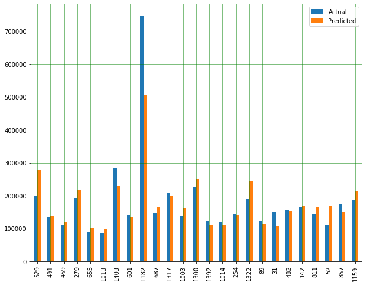

```python
df_bar1.plot(kind='bar',figsize=(10,8))
plt.grid(which='major', linestyle='-', linewidth='0.5', color='green')
plt.grid(which='minor', linestyle=':', linewidth='0.5', color='black')
plt.show()
```

```python
print('Mean Absolute Error:', metrics.mean_absolute_error(y_test, y_pred))
print('Mean Squared Error:', metrics.mean_squared_error(y_test, y_pred))
print('Root Mean Squared Error:', np.sqrt(metrics.mean_squared_error(y_test, y_pred)))
print('R-squared Error:', metrics.r2_score(y_test, y_pred))
```

```
Mean Absolute Error: 26149.649195726415
Mean Squared Error: 2896623850.136266
Root Mean Squared Error: 53820.29217810199
R-squared Error: 0.5805550561864522
```

```python
y_pred = regressor.predict(test)
y_pred
```

```
array([129868.8700819 , 153317.80980719, 197133.69383655, ...,
       185561.2900273 , 107378.06943003, 228496.47938846])
```

### Normalization of data

```python
from sklearn.preprocessing import MinMaxScaler
scaling = MinMaxScaler()
scaling.fit_transform(train)
```

```
array([[0.66666667, 0.25923135, 0.38822705, ..., 0.0334198 , 0.15068493,
        0.24107763],
       [1.        , 0.17483044, 0.32585844, ..., 0.03879502, 0.20205479,
        0.20358284],
       [0.66666667, 0.27354936, 0.4302733 , ..., 0.04650728, 0.1609589 ,
        0.26190807],
       ...,
       [0.        , 0.37792012, 0.18079888, ..., 0.03618687, 0.15410959,
        0.321622  ],
       [1.        , 0.14016579, 0.17098809, ..., 0.03934189, 0.1609589 ,
        0.14890293],
       [0.66666667, 0.17370008, 0.19621584, ..., 0.04037019, 0.18493151,
        0.15636717]])
```

```python
X = train.drop(["SalePrice"], 1)
y = train["SalePrice"]
```

```python
X_train, X_test, y_train, y_test = train_test_split(X, y, test_size=0.2, random_state=0)
```

```python
regressor = LinearRegression()
regressor.fit(X_train, y_train)
```

```
LinearRegression(copy_X=True, fit_intercept=True, n_jobs=None, normalize=False)
```

```python
y_pred = regressor.predict(X_test)
```

```python
print('Mean Absolute Error:', metrics.mean_absolute_error(y_test, y_pred))
print('Mean Squared Error:', metrics.mean_squared_error(y_test, y_pred))
print('Root Mean Squared Error:', np.sqrt(metrics.mean_squared_error(y_test, y_pred)))
print('R-squared Error:', metrics.r2_score(y_test, y_pred))
```

```
Mean Absolute Error: 26149.649195726415
Mean Squared Error: 2896623850.136266
Root Mean Squared Error: 53820.29217810199
R-squared Error: 0.5805550561864522
```

### Applying Decision tree regression

```python
from sklearn.tree import DecisionTreeRegressor
from sklearn.tree import export_graphviz
```

```python
X = train.drop(["SalePrice"], 1)
y = train["SalePrice"]
```

```python
X_train, X_test, y_train, y_test = train_test_split(X, y, test_size=0.2, random_state=0)
```

```python
dt = DecisionTreeRegressor()
```

```python
dt.fit(X_train, y_train)
```

```
DecisionTreeRegressor(criterion='mse', max_depth=None, max_features=None,
                      max_leaf_nodes=None, min_impurity_decrease=0.0,
                      min_impurity_split=None, min_samples_leaf=1,
                      min_samples_split=2, min_weight_fraction_leaf=0.0,
                      presort=False, random_state=None, splitter='best')
```

```python
y_pred =dt.predict(X_test)
```

```python
print('Mean Absolute Error:', metrics.mean_absolute_error(y_test, y_pred))
print('Mean Squared Error:', metrics.mean_squared_error(y_test, y_pred))
print('Root Mean Squared Error:', np.sqrt(metrics.mean_squared_error(y_test, y_pred)))
print('R-squared Error:', metrics.r2_score(y_test, y_pred))
```

```
Mean Absolute Error: 30529.969178082192
Mean Squared Error: 2830620142.989726
Root Mean Squared Error: 53203.57265249887
R-squared Error: 0.5901127076689753
```

```python
import graphviz
graphviz.Source(export_graphviz(dt,
                                out_file=None,
                                filled=True,
                                rounded=True,
                                special_characters=True,
                                feature_names=['ExterQual','total_floors','Garage_Overall','GrLivArea','BsmtFinSF1','BsmtQual','MasVnrArea','GarageYrBlt','LotArea','LotFrontage']))
```

[figure not shown]

```python
y_pred = dt.predict(test)
y_pred
```

```
array([135000., 170000., 200000., ..., 166000.,  80000., 252678.])
```

## Improving the Model

**Improving the model using StandardScaler**

```python
X = train.drop(["SalePrice"], 1)
y = train["SalePrice"]
```

```python
X_train, X_test, y_train, y_test = train_test_split(X, y, test_size=0.2, random_state=0)
```

```python
from sklearn.preprocessing import StandardScaler
scaler = StandardScaler(with_mean=False)
scaler.fit(X_train)
x_train_scaled = scaler.transform(X_train)
x_val_scaled = scaler.transform(X_test)
x_train_scaled
```

```
array([[ 0.        ,  3.58902379,  3.72633119, ..., 82.7827961 ,
         1.0929383 ,  4.33736237],
       [ 4.38214024,  1.75524468,  1.48958067, ..., 80.9266796 ,
         0.61684563,  2.89157491],
       [ 4.38214024,  1.89267994,  2.07970208, ..., 79.23555122,
         1.2486451 ,  3.85543322],
       ...,
       [ 4.38214024,  3.7343125 ,  2.5936788 , ..., 81.58663213,
         0.83461083,  3.27711823],
       [ 2.92142683,  3.05695298,  2.03211165, ..., 82.61780797,
         0.29870282,  3.32531115],
       [ 2.92142683,  3.61062076,  2.34620853, ..., 82.4115728 ,
         1.56734867,  2.79518908]])
```

```python
dt = DecisionTreeRegressor()
```

```python
dt.fit(X_train, y_train)
```

```
DecisionTreeRegressor(criterion='mse', max_depth=None, max_features=None,
                      max_leaf_nodes=None, min_impurity_decrease=0.0,
                      min_impurity_split=None, min_samples_leaf=1,
                      min_samples_split=2, min_weight_fraction_leaf=0.0,
                      presort=False, random_state=None, splitter='best')
```

```python
y_pred =dt.predict(X_test)
```

```python
print('Mean Absolute Error:', metrics.mean_absolute_error(y_test, y_pred))
print('Mean Squared Error:', metrics.mean_squared_error(y_test, y_pred))
print('Root Mean Squared Error:', np.sqrt(metrics.mean_squared_error(y_test, y_pred)))
print('R-squared Error:', metrics.r2_score(y_test, y_pred))
```

```
Mean Absolute Error: 29796.253424657534
Mean Squared Error: 2802771521.890411
Root Mean Squared Error: 52941.20816424962
R-squared Error: 0.5941453207787988
```

### Applying SVM for Regression

```python
from sklearn.svm import SVR
```

```python
X =train.drop(["SalePrice"], 1)
y =train["SalePrice"]
```

```python
X_train, X_test, y_train, y_test = train_test_split(X, y, test_size=0.3, random_state=0)
```

```python
model=SVR()
model.fit(X_train,y_train)
```

```
SVR(C=1.0, cache_size=200, coef0=0.0, degree=3, epsilon=0.1,
    gamma='auto_deprecated', kernel='rbf', max_iter=-1, shrinking=True,
    tol=0.001, verbose=False)
```

```python
y_pred = model.predict(X_test)
y_pred
```

[output not shown]

[output cut: 55 more lines]

```
       162999.4       , 162999.4       , 162999.4       , 162999.4       ,
       162999.4       , 162999.4       , 162999.4       , 162999.4       ,
       162999.4       , 162999.4       , 162999.4       , 162999.4       ,
       162999.4       , 162999.4       , 162999.4       , 162999.4       ,
       162999.4       , 162999.4       , 162999.4       , 162999.4       ,
       162999.4       , 162999.4       , 162999.4       , 162999.4       ,
       162999.4       , 162999.4       , 162999.4       , 162999.4       ,
       162999.4       , 162999.4       , 162999.4       , 162999.4       ,
       162999.4       , 162999.4       , 162999.4       , 162999.4       ,
       162999.4       , 162999.4       , 162999.4       , 162999.4       ,
       162999.4       , 162999.4       , 162999.4       , 162999.4       ,
       162999.4       , 162999.4       , 162999.4       , 162999.4       ,
       162999.4       , 162999.4       , 162999.4       , 162999.4       ,
       162999.4       , 162999.4       , 162999.4       , 162999.4       ,
       162999.4       , 162999.4       ])
```

```python
print('Mean Absolute Error:', metrics.mean_absolute_error(y_test, y_pred))
print('Mean Squared Error:', metrics.mean_squared_error(y_test, y_pred))
print('Root Mean Squared Error:', np.sqrt(metrics.mean_squared_error(y_test, y_pred)))
print('R-squared Error:', metrics.r2_score(y_test, y_pred))
```

```
Mean Absolute Error: 56468.60112390868
Mean Squared Error: 7138807943.774003
Root Mean Squared Error: 84491.46669205124
R-squared Error: -0.051527020744233765
```

```python
y_pred = model.predict(test)
y_pred
```

```
array([162999.4, 162999.4, 162999.4, ..., 162999.4, 162999.4, 162999.4])
```

**As we can see that R-square value is very low which mneans SVM is not a good regressor to predict prices**

### Impoving the model

```python
X = train.drop(["SalePrice"], 1)
y = train["SalePrice"]
```

```python
X_train, X_test, y_train, y_test = train_test_split(X, y, test_size=0.3, random_state=0)
```

```python
from sklearn.preprocessing import StandardScaler
scaler = StandardScaler(with_mean=False)
scaler.fit(X_train)
x_train_scaled = scaler.transform(X_train)
x_val_scaled = scaler.transform(X_test)
x_train_scaled
```

```
array([[4.48963985e+00, 3.95867759e+00, 3.11265729e+00, ...,
        8.21932763e+01, 9.11411704e-01, 3.31347548e+00],
       [4.48963985e+00, 2.51261198e+00, 2.08624423e+00, ...,
        8.21110007e+01, 2.80666196e-01, 3.31347548e+00],
       [4.48963985e+00, 1.66988465e+00, 2.38700713e-02, ...,
        8.14527963e+01, 7.00644710e-01, 2.40106919e+00],
       ...,
       [4.48963985e+00, 3.70177226e+00, 2.60183777e+00, ...,
        8.13705207e+01, 8.68150029e-01, 3.26545410e+00],
       [2.99309323e+00, 3.03031514e+00, 2.03850409e+00, ...,
        8.23989651e+01, 3.10706326e-01, 3.31347548e+00],
       [2.99309323e+00, 3.57915835e+00, 2.35358903e+00, ...,
        8.21932763e+01, 1.63033326e+00, 2.78524026e+00]])
```

```python
model=SVR()
model.fit(X_train,y_train)
```

```
SVR(C=1.0, cache_size=200, coef0=0.0, degree=3, epsilon=0.1,
    gamma='auto_deprecated', kernel='rbf', max_iter=-1, shrinking=True,
    tol=0.001, verbose=False)
```

```python
y_pred = model.predict(X_test)
y_pred
```

[output not shown]

[output cut: 55 more lines]

```
       162999.4       , 162999.4       , 162999.4       , 162999.4       ,
       162999.4       , 162999.4       , 162999.4       , 162999.4       ,
       162999.4       , 162999.4       , 162999.4       , 162999.4       ,
       162999.4       , 162999.4       , 162999.4       , 162999.4       ,
       162999.4       , 162999.4       , 162999.4       , 162999.4       ,
       162999.4       , 162999.4       , 162999.4       , 162999.4       ,
       162999.4       , 162999.4       , 162999.4       , 162999.4       ,
       162999.4       , 162999.4       , 162999.4       , 162999.4       ,
       162999.4       , 162999.4       , 162999.4       , 162999.4       ,
       162999.4       , 162999.4       , 162999.4       , 162999.4       ,
       162999.4       , 162999.4       , 162999.4       , 162999.4       ,
       162999.4       , 162999.4       , 162999.4       , 162999.4       ,
       162999.4       , 162999.4       , 162999.4       , 162999.4       ,
       162999.4       , 162999.4       , 162999.4       , 162999.4       ,
       162999.4       , 162999.4       ])
```

```python
print('Mean Absolute Error:', metrics.mean_absolute_error(y_test, y_pred))
print('Mean Squared Error:', metrics.mean_squared_error(y_test, y_pred))
print('Root Mean Squared Error:', np.sqrt(metrics.mean_squared_error(y_test, y_pred)))
print('R-squared Error:', metrics.r2_score(y_test, y_pred))
```

```
Mean Absolute Error: 56468.60112390868
Mean Squared Error: 7138807943.774003
Root Mean Squared Error: 84491.46669205124
R-squared Error: -0.051527020744233765
```